# Ancestry assignment across ieu-a / ieu-b / bbj-a

815 GWAS · genome-wide · AF-recovered ancestry vs reported population

Published

July 11, 2026

## Overview

Every GWAS in the **`ieu-a` (464), `ieu-b` (225) and `bbj-a` (126)** collections — 815 studies — assigned an ancestry from its **summary-statistic allele frequencies**, genome-wide (ADR 0028). The studies are GRCh37, so they are matched against a **hg19** reference (the raw Privé 2022 UK-Biobank 21-group panel, 5.8 M variants, kept on hg19) — study and reference share coordinates, so no liftover is involved. Each study’s frequencies are fit as an NNLS mixture, aggregated to super-populations, and admitted only if they clear the calibrated gates: **τ ≥ 0.50, δ ≥ 0.20, overlap ≥ 5,000, residual ≤ 0.06**.

|  | count | share |
| --- | --- | --- |
| **Assigned** | 527 | 65% |
| Unassigned | 288 | 35% |
| — no usable allele frequencies (overlap gate) | 193 | 24% |
| — allele frequencies inconsistent w/ reference (residual gate) | 95 | 12% |

## Assigned-ancestry distribution

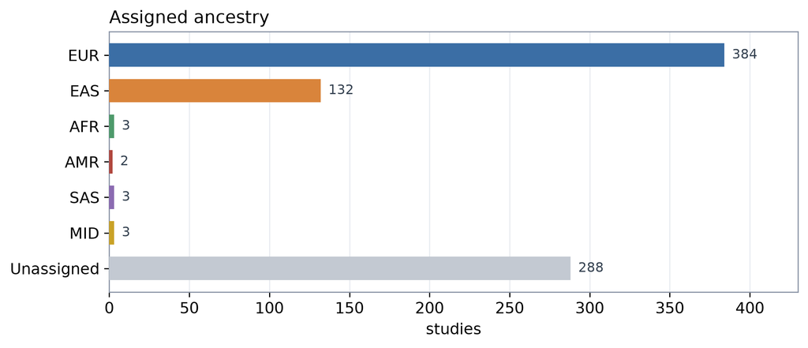

Assigned super-population across all 815 studies (Unassigned shown for scale).

Of the **527 assigned** studies, EUR and EAS dominate (the collections are European and Biobank-Japan heavy), with small numbers of AFR, AMR, SAS and MID recovered directly from the frequencies.

## Reported vs Assigned — the audit

| Reported ＼ Assigned | EUR | EAS | AFR | AMR | SAS | MID | Unassigned | total |
| --- | --- | --- | --- | --- | --- | --- | --- | --- |
| European | 319 | · | · | · | · | · | 257 | **576** |
| East Asian | · | 132 | · | · | · | · | 9 | **141** |
| Mixed | 61 | · | · | · | · | · | 21 | **82** |
| Hispanic / Latino | 4 | · | · | 2 | · | · | · | **6** |
| African | · | · | 3 | · | · | · | 1 | **4** |
| South Asian | · | · | · | · | 3 | · | · | **3** |
| Iranian | · | · | · | · | · | 3 | · | **3** |